# Piecewise Structural Equation Modelling

Laurel Wellman

2024-01-31

*PSEM example provided by John M. Wallace*

# Basic overview of the method:

**PIECEWISE SEM**: Fit models for each response and then piece together inferences using tests of direct separation by fitting missing relationships to test whether path coefficients are significantly different from zero.

*Chi-square test statistic* compares observed vs. estimated variance-covariance matrices. Significance indicates that missing information (i.e., path) would improve model fit.

**STEP 1**: Local estimation of models (hierarchcial structure, generalized linear, etc.)

**STEP 2**: Structured hypothesis - Identify set of missing relationships using “basis set”

**STEP 3**: Test whether effect is not significantly different from zero (p > 0.05) when controlling for covariates already specified in model; i.e, the test considers the partial effect of one variable on response if either or both are already connect to other variables in the model

**STEP 4**: Identify best fit model & report path diagram w/ standardized path coefficients, significance-levels, marginal & conditional r2, correlation coefficients

**STEP 5**: Use SEM to extract partial residuals (effects) and model separately when appropriate

# Data wrangling

```r
psa<-read.csv("https://raw.githubusercontent.com/lew5444/Statistics-Tutorials/main/PSA-CE2-Weeds-Yield-Rye-Compiled.csv", na.strings='na')
psa$Rye.kgha <- as.integer(psa$Rye.kgha)
psa$CC.win <- as.integer(psa$CC.win) # create continuous variable for "CC termination window; 0 to 21 days"
psa$RR.tot <- psa$Total_density/psa$UTC.tot.density.rep # create response ratio standardized to no cover control at replicate level
psa$LRR.tot <- log((psa$Total_density/psa$UTC.tot.density.rep)+0.01) # log response ratio
psa <- subset(psa, Herb == "POST")
psa <- subset(psa, Crop == "Corn"|Crop == "Beans")
psa <- subset(psa, CC == "1-3 DAP"|CC == "14-21 DPP"|CC == "3-7 DPP")
```

# **Step 1-1: Local Estimation:** *Model 1* *cover crop response to planting date*

## 1.Inspect univariate statistics

*check data by using summary (ie length is right, no missing data)*

```r
summary <- psa %>% # name new dataset (summary) and call raw data set to summarize (data)
  group_by (CC, CC.win, CropYear, Block) %>% # identify explanatory variables you want to summarize over
  summarise_at(vars(Rye.kgha), funs(mean, length)) # identify predictor variables (can multiple) and type of summary stat
print.data.frame(summary) # output summary table
```

```
##           CC CC.win CropYear Block mean length
## 1    1-3 DAP     21  Beans22    B1 2397      1
## 2    1-3 DAP     21  Beans22    B2 2316      1
## 3    1-3 DAP     21  Beans22    B3 3547      1
## 4    1-3 DAP     21  Beans22    B4 3002      1
## 5    1-3 DAP     21  Beans22    B5 3579      1
## 6    1-3 DAP     21   Corn21    B1 5375      1
## 7    1-3 DAP     21   Corn21    B2 5882      1
## 8    1-3 DAP     21   Corn21    B3 4966      1
## 9    1-3 DAP     21   Corn21    B4 5313      1
## 10   1-3 DAP     21   Corn21    B5 4928      1
## 11   1-3 DAP     21   Corn22    B1 5334      1
## 12   1-3 DAP     21   Corn22    B2 4741      1
## 13   1-3 DAP     21   Corn22    B3 5456      1
## 14   1-3 DAP     21   Corn22    B4 6285      1
```

[output cut: 31 more lines]

## 2a. LME Regression (check homogeneity of variance)

*check assumptions of normaility and homogeneity to see if you need to transform data*

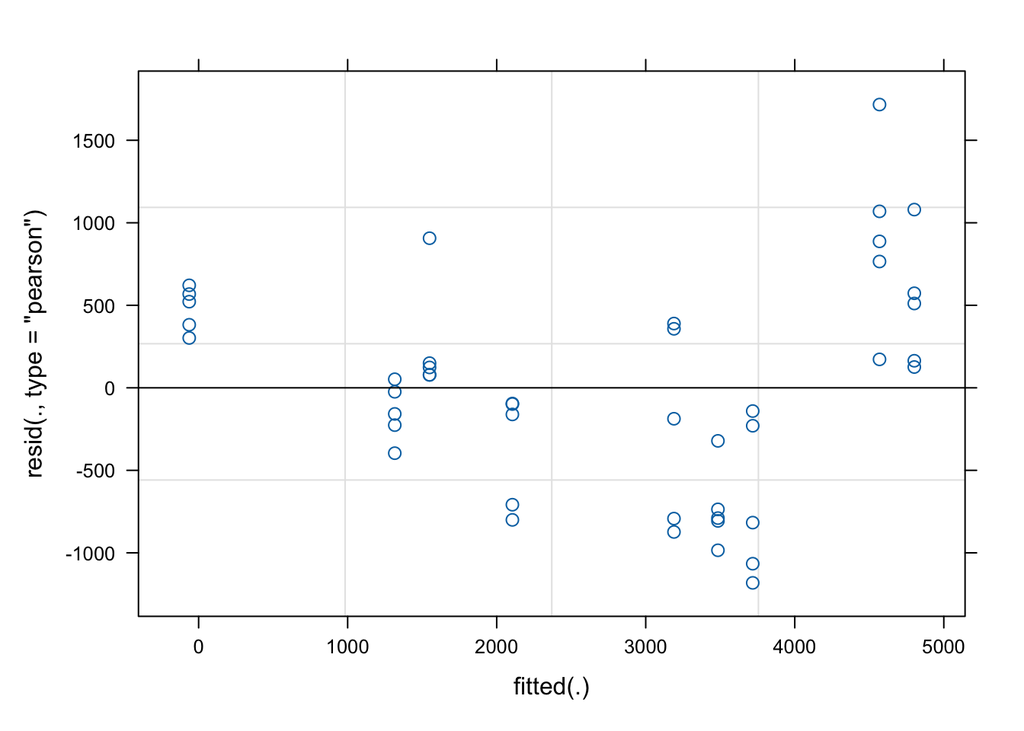

```r
m1 <- lmer(Rye.kgha ~ CC.win + (1|CropYear), data = psa, na.action = na.omit)
plot(m1)
```

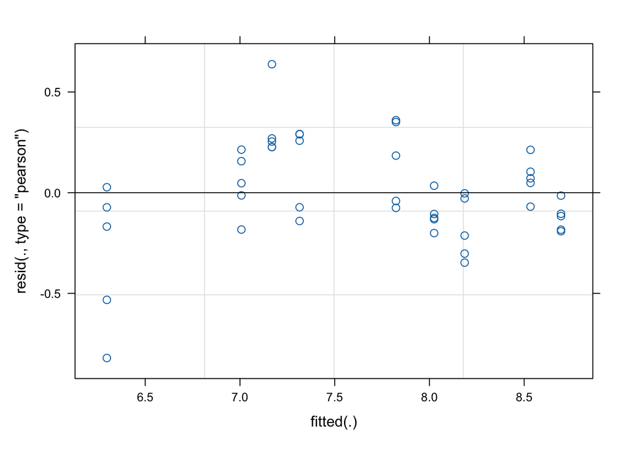

```r
m2 <- lmer(log(Rye.kgha) ~ CC.win + (1|CropYear), data = psa, na.action = na.omit)
plot(m2)  # inspect residuals to inspect homogeneity of variance (choose best fit)
```

```r
anova (m1, m2)
```

```
## refitting model(s) with ML (instead of REML)
```

```
## Data: psa
## Models:
## m1: Rye.kgha ~ CC.win + (1 | CropYear)
## m2: log(Rye.kgha) ~ CC.win + (1 | CropYear)
##    npar    AIC    BIC  logLik deviance  Chisq Df Pr(>Chisq)
## m1    4 729.59 736.81 -360.79   721.59
## m2    4  24.43  31.65   -8.21    16.43 705.16  0
```

## 2b. LME Regression (random intercept model vs. random intercept/slope model)

```r
m1 <- lmer(log(Rye.kgha) ~ CC.win + (1|CropYear), data = psa, na.action = na.omit) # Random intercept model
m2 <- lmer(log(Rye.kgha) ~ CC.win + (CC.win|CropYear), data = psa, na.action = na.omit) # Random intercept and slope model
anova(m1, m2) # check AICs
```

```
## refitting model(s) with ML (instead of REML)
```

```
## Data: psa
## Models:
## m1: log(Rye.kgha) ~ CC.win + (1 | CropYear)
## m2: log(Rye.kgha) ~ CC.win + (CC.win | CropYear)
##    npar     AIC    BIC  logLik deviance  Chisq Df Pr(>Chisq)
## m1    4 24.4279 31.655 -8.2139  16.4279
## m2    6  6.9601 17.800  2.5200  -5.0399 21.468  2  2.179e-05 ***
## ---
## Signif. codes:  0 '***' 0.001 '**' 0.01 '*' 0.05 '.' 0.1 ' ' 1
```

## 3.Extract test-statistics and parameter estimates of best fit model

```r
m0 <- lmer(log(Rye.kgha) ~ (CC.win|CropYear), data = psa, na.action = na.omit)
m1 <- lmer(log(Rye.kgha) ~ CC.win + (CC.win|CropYear), data = psa, na.action = na.omit)
```

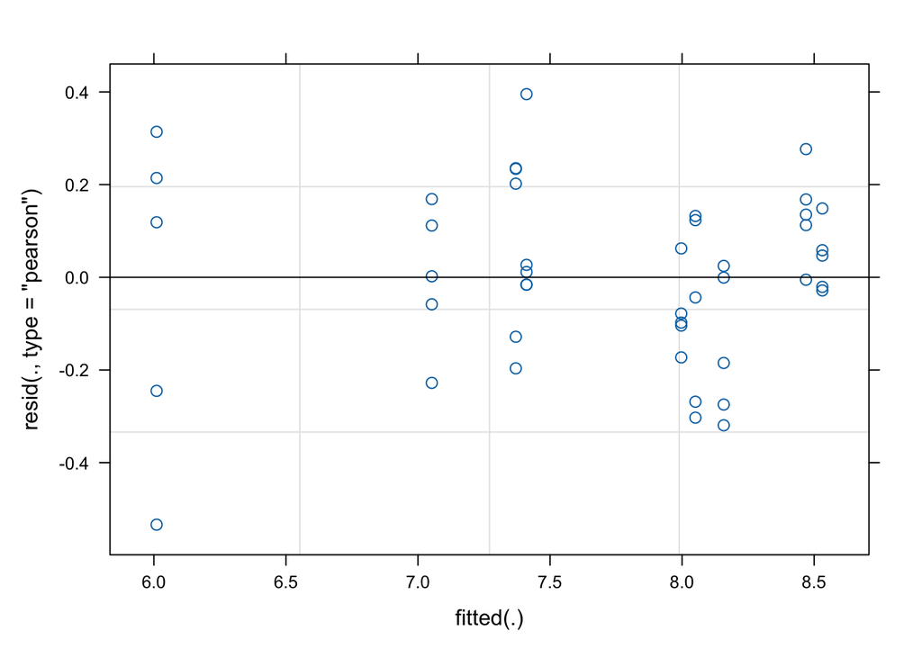

```r
plot(m1)  # inspect residuals to inspect homogeneity of variance (choose best fit)
```

```r
summary(m1) # inspect parameter estimates
```

```
## Linear mixed model fit by REML ['lmerMod']
## Formula: log(Rye.kgha) ~ CC.win + (CC.win | CropYear)
##    Data: psa
##
## REML criterion at convergence: 5.1
##
## Scaled residuals:
##      Min       1Q   Median       3Q      Max
## -2.68047 -0.52274  0.01094  0.66440  1.98492
##
## Random effects:
##  Groups   Name        Variance  Std.Dev. Corr
##  CropYear (Intercept) 0.5231345 0.72328
##           CC.win      0.0005031 0.02243  -0.99
##  Residual             0.0396636 0.19916
## Number of obs: 45, groups:  CropYear, 3
##
## Fixed effects:
##             Estimate Std. Error t value
## (Intercept)  6.82452    0.42052  16.229
## CC.win       0.07266    0.01339   5.426
##
## Correlation of Fixed Effects:
##        (Intr)
## CC.win -0.977
## optimizer (nloptwrap) convergence code: 0 (OK)
## Model failed to converge with max|grad| = 0.0237357 (tol = 0.002, component 1)
```

```r
anova(m0, m1) # model significance: extract Wald Chi Sq & p-value
```

```
## refitting model(s) with ML (instead of REML)
```

```
## Data: psa
## Models:
## m0: log(Rye.kgha) ~ (CC.win | CropYear)
## m1: log(Rye.kgha) ~ CC.win + (CC.win | CropYear)
##    npar     AIC    BIC logLik deviance  Chisq Df Pr(>Chisq)
## m0    5 13.1619 22.195 -1.581   3.1619
## m1    6  6.9601 17.800  2.520  -5.0399 8.2018  1   0.004185 **
## ---
## Signif. codes:  0 '***' 0.001 '**' 0.01 '*' 0.05 '.' 0.1 ' ' 1
```

```r
library(piecewiseSEM) # package to extract marginal & conditional r2 values
rsquared(m1, method=NULL) # use to extract conditional r2 value
```

```
##   Response   family     link method  Marginal Conditional
## 1 Rye.kgha gaussian identity   none 0.5831677    0.943791
```

`rsquared()` produces two $R^{2}$ values: marginal and conditiona.

Marginal $R^{2}$ tells you what proportion of the variance is explained by fixed effects.

Conditional $R^{2}$ tells you the proportion of variance is explained by both random and fixed effects together. What’s left over is the residual error.

## 4a. Extract and plot fitted model at the *random effects level*

```r
#library(merTools)
psa$fit.ranef = predict(m1)
psa$fit.ranef
```

```
##  [1] 8.050520 6.010299 7.370446 8.050520 7.370446 6.010299 7.370446 6.010299
##  [9] 8.050520 8.050520 6.010299 7.370446 6.010299 8.050520 7.370446 8.531068
## [17] 7.410979 8.157705 8.531068 8.157705 7.410979 8.157705 7.410979 8.531068
## [25] 8.531068 7.410979 8.157705 7.410979 8.531068 8.157705 8.469264 7.052272
## [33] 7.996933 8.469264 7.996933 7.052272 7.996933 7.052272 8.469264 8.469264
## [41] 7.052272 7.996933 7.052272 8.469264 7.996933
```

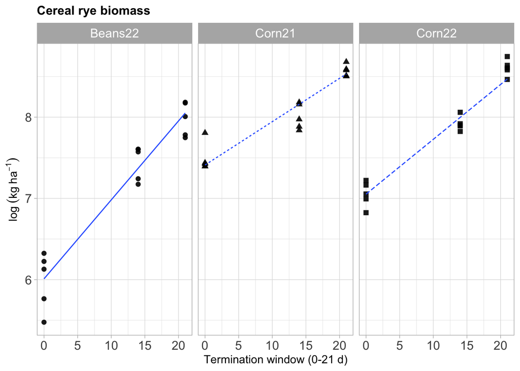

```r
fig.rand <- ggplot(psa, aes(x = CC.win, y = log(Rye.kgha), shape = CropYear)) +
  theme_light() +
  geom_point(size=2.0, alpha=0.9) + # point features
  geom_smooth(method="lm", aes(x = CC.win, y = fit.ranef, lty = CropYear), size = 0.5, alpha = 0.2) +
  facet_grid (. ~ CropYear) +
  ylab ("log" ~ (kg ~ ha^{-1})) +
  xlab("Termination window (0-21 d)") +
  ggtitle ("Cereal rye biomass") +
  theme(legend.position = "none") +
  theme(legend.title = element_blank()) +
  theme(axis.text.x = element_text(size=12)) +
  theme(axis.text.y = element_text(size=12)) +
  theme(strip.text.x = element_text(size = 12)) +
  theme(plot.title = element_text(size = 12, face = "bold"))
fig.rand
```

```r
# extra code
 #theme(axis.title.y = element_blank()) +
  #theme(panel.grid.minor.x = element_blank()) +
  #theme(panel.grid.major.x = element_blank()) +
  #scale_fill_manual(values=c("14-21 DPP" = "peru", "3-7 DPP"="gold", "1-3 DAP"="sea green")) +
  #scale_color_manual(values=c("14-21 DPP" = "peru", "3-7 DPP"="gold", "1-3 DAP"="sea green")) +
  #scale_x_continuous (limits = c(0, 1)) +
  #scale_y_continuous (limits = c(-99, 20)) + # setting axis range; scale_y_continuous or scale_x_continuous
```

## 4b. Extract and plot fitted model at the *population level*

model averaged over regression coefficients

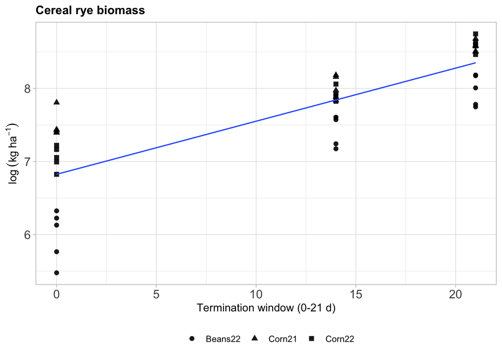

```r
psa$fit.popef = predict(m1, re.form = NA)
fig.popest <- ggplot(psa, aes(x = CC.win, y = log(Rye.kgha), shape = CropYear)) +
  theme_light() +
  geom_point(size=2.0, alpha=0.9) + # point features
  geom_smooth(method="lm", aes(x = CC.win, y = fit.popef), size = 0.5, alpha = 0.2) +
  ylab ("log" ~ (kg ~ ha^{-1})) +
  xlab("Termination window (0-21 d)") +
  ggtitle ("Cereal rye biomass") +
  theme(legend.position = "bottom") +
  theme(legend.title = element_blank()) +
  theme(axis.text.x = element_text(size=12)) +
  theme(axis.text.y = element_text(size=12)) +
  theme(strip.text.x = element_text(size = 12)) +
  theme(plot.title = element_text(size = 12, face = "bold"))
fig.popest
```

```r
  #theme(axis.title.y = element_blank()) +
  #theme(panel.grid.minor.x = element_blank()) +
  #theme(panel.grid.major.x = element_blank()) +
  #scale_fill_manual(values=c("14-21 DPP" = "peru", "3-7 DPP"="gold", "1-3 DAP"="sea green")) +
  #scale_color_manual(values=c("14-21 DPP" = "peru", "3-7 DPP"="gold", "1-3 DAP"="sea green")) +
  #scale_x_continuous (limits = c(0, 1)) +
  #scale_y_continuous (limits = c(-99, 20)) + # setting axis range; scale_y_continuous or scale_x_continuous
  #####
  #ggsave(file="/Users/johnwallace/Documents/Documents/R/PSA.f1.jpg", scale=1.5, width=4.0, #height=2.0, units="in", dpi=900)
```

## 5a. Extract and plot *intercepts* for random effects (i.e., BLUPs or conditional means)

```r
#library(broom.mixed) # package for extracting random effects of interest w/ CIs
r1 <- broom.mixed::tidy(m1, effects = "ran_vals", conf.int = TRUE, response = TRUE)
as.data.frame(r1) ### conditional means (interclass correlation coefficient (ICC)). conditioned on pop level estimate (relative to 0)
```

```
##     effect    group   level        term     estimate   std.error    conf.low
## 1 ran_vals CropYear Beans22 (Intercept) -0.814217546 0.077580792 -0.96627310
## 2 ran_vals CropYear  Corn21 (Intercept)  0.586462131 0.077580792  0.43440657
## 3 ran_vals CropYear  Corn22 (Intercept)  0.227755414 0.077580792  0.07569986
## 4 ran_vals CropYear Beans22      CC.win  0.024497773 0.003829795  0.01699151
## 5 ran_vals CropYear  Corn21      CC.win -0.019317995 0.003829795 -0.02682425
## 6 ran_vals CropYear  Corn22      CC.win -0.005179778 0.003829795 -0.01268604
##      conf.high
## 1 -0.662161987
## 2  0.738517690
## 3  0.379810973
## 4  0.032004032
## 5 -0.011811735
## 6  0.002326482
```

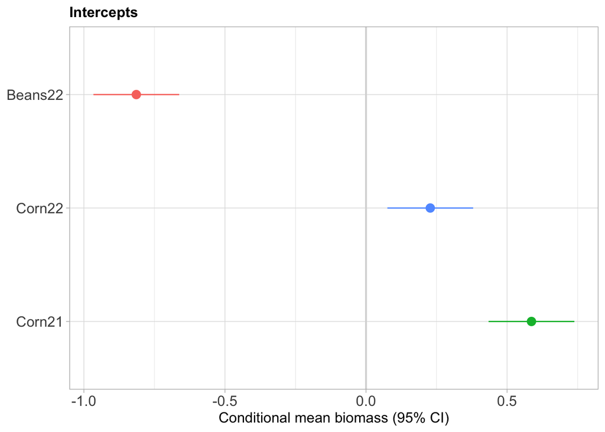

```r
intercept <- subset(r1, term == "(Intercept)")
fig.int <-ggplot(intercept, aes (x = reorder(level, -estimate), y = estimate, ymin = conf.low, ymax = conf.high, fill = level, color = level, shape = level)) + # extracted from summary data
  geom_hline(yintercept = 0, color = "gray85", size=0.75) +
  geom_errorbar(width = 0.0, size=0.5, position=position_dodge(0.9)) +
  geom_point(size=3.0, shape=21, position=position_dodge(0.9)) +
  coord_flip() +
  ggtitle ("Intercepts") + # optional title in quotes
  theme_light () + # several themes available, other: theme_minimal, theme_grey, theme_classic
  xlab (NULL) + # use this to remove axis title
  ylab ("Conditional mean biomass (95% CI)") + #Label syntax is complicated; but is a typical layout
  theme(legend.position = "NULL") + #legend placement, can be: right, left, top
  theme(legend.title=element_blank()) + #removes legend title
  theme(axis.text.x = element_text(size=12)) +
  theme(axis.text.y = element_text(size=12)) +
  theme(axis.title.y = element_text(size=12)) +
  theme(axis.title.x = element_text(size=12)) +
  #theme(panel.grid.major.x = element_blank()) +
  #theme(panel.grid.major.y = element_blank()) +
  #theme(panel.grid.minor.x = element_blank()) +
  theme(plot.title = element_text(size = 12, face = "bold"))
fig.int
```

Here, 0 is the population level estimate. This shows deviation from the overall average.

## 5b. Extract and plot *slopes* for random effects (i.e., BLUPs or conditional means)

```r
r1 <- broom.mixed::tidy(m1, effects = "ran_vals", conf.int = TRUE, response = TRUE)
as.data.frame(r1)
```

```
##     effect    group   level        term     estimate   std.error    conf.low
## 1 ran_vals CropYear Beans22 (Intercept) -0.814217546 0.077580792 -0.96627310
## 2 ran_vals CropYear  Corn21 (Intercept)  0.586462131 0.077580792  0.43440657
## 3 ran_vals CropYear  Corn22 (Intercept)  0.227755414 0.077580792  0.07569986
## 4 ran_vals CropYear Beans22      CC.win  0.024497773 0.003829795  0.01699151
## 5 ran_vals CropYear  Corn21      CC.win -0.019317995 0.003829795 -0.02682425
## 6 ran_vals CropYear  Corn22      CC.win -0.005179778 0.003829795 -0.01268604
##      conf.high
## 1 -0.662161987
## 2  0.738517690
## 3  0.379810973
## 4  0.032004032
## 5 -0.011811735
## 6  0.002326482
```

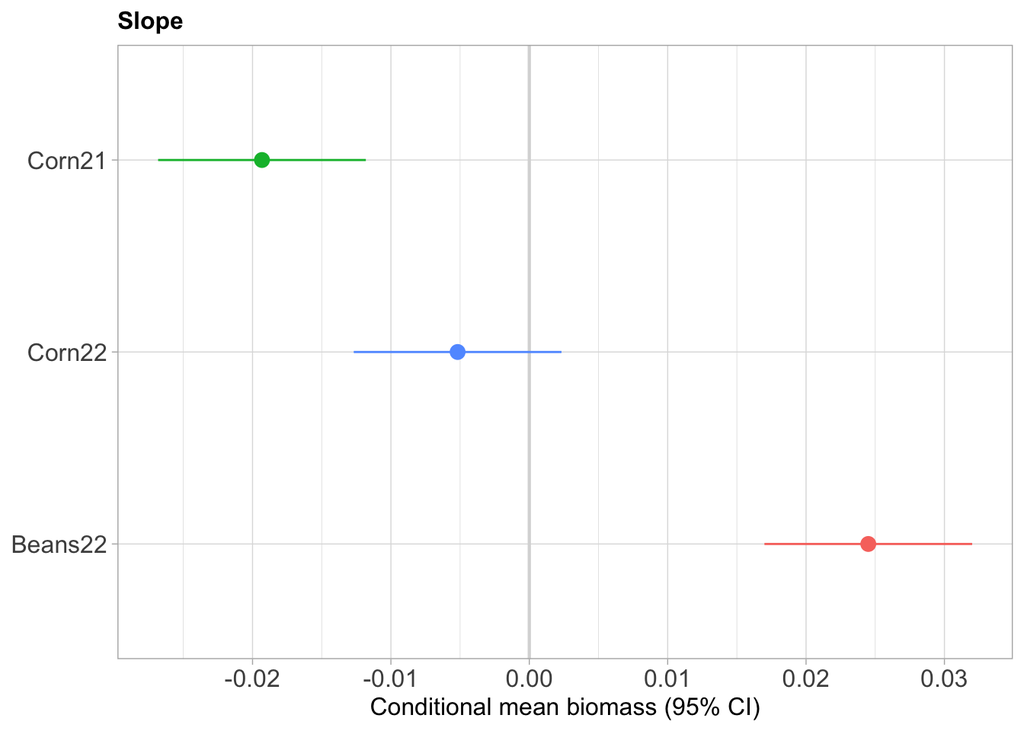

```r
slope <- subset(r1, term == "CC.win")
fig.int <-ggplot(slope, aes (x = reorder(level, -estimate), y = estimate, ymin = conf.low, ymax = conf.high, fill = level, color = level, shape = level)) + # extracted from summary data
  geom_hline(yintercept = 0, color = "gray85", size=0.75) +
  geom_errorbar(width = 0.0, size=0.5, position=position_dodge(0.9)) +
  geom_point(size=3.0, shape=21, position=position_dodge(0.9)) +
  coord_flip() +
  ggtitle ("Slope") + # optional title in quotes
  theme_light () + # several themes available, other: theme_minimal, theme_grey, theme_classic
  xlab (NULL) + # use this to remove axis title
  ylab ("Conditional mean biomass (95% CI)") + #Label syntax is complicated; but is a typical layout
  #scale_y_continuous (limits = c(-60, 60)) + # setting axis range; scale_y_continuous or scale_x_continuous
  theme(legend.position = "NULL") + #legend placement, can be: right, left, top
  theme(legend.title=element_blank()) + #removes legend title
  theme(axis.text.x = element_text(size=12)) +
  theme(axis.text.y = element_text(size=12)) +
  theme(axis.title.y = element_text(size=12)) +
  theme(axis.title.x = element_text(size=12)) +
  #theme(panel.grid.major.x = element_blank()) +
  #theme(panel.grid.major.y = element_blank()) +
  #theme(panel.grid.minor.x = element_blank()) +
  theme(plot.title = element_text(size = 12, face = "bold"))

fig.int
```

```r
#ggsave(file="/Users/johnwallace/Documents/Documents/R/PSA.f1.jpg", scale=1.5, width=4.0, height=2.0, units="in", dpi=900)
```

## 6. ICC (Intraclass Correlation Coefficients) *for nested structures*

This is the proportion of total variance explained at each grouping level

```r
icc <-  VarCorr(m1) %>%
  as_data_frame() %>%
  mutate(icc=vcov/sum(vcov))
icc.df <- as.data.frame(icc)
icc.df
```

```
##        grp        var1   var2          vcov       sdcor           icc
## 1 CropYear (Intercept)   <NA>  0.5231345237  0.72328039  0.9560053818
## 2 CropYear      CC.win   <NA>  0.0005031111  0.02243014  0.0009194135
## 3 CropYear (Intercept) CC.win -0.0160924211 -0.99193391 -0.0294081933
## 4 Residual        <NA>   <NA>  0.0396635507  0.19915710  0.0724833980
```

[figure not shown]

```r
var <- c("Variable", "Variable")
grp <- c("GroupA", "Groupb")
icc <- c(00, 00) # input these ICC scores icc.df data frame using percentages
df <- data.frame(var, grp, icc) # create a data frame
df$grp = factor(df$grp, levels=c("GroupA", "GroupB")) # Order explanatory variables in order of ICC score (descending)
cbPalette <- c("#999999", "#E69F00")
ICC.plot <-ggplot(df, aes (x = var, y = icc)) + # extracted from summary data
  #geom_bar(aes(fill=grp, position="fill", stat="identity")) + # use this when you have more than one stacked bar
  geom_col(aes(fill=grp)) + # use this if plotting a single stacked bar
  coord_flip() +
  ggtitle ("Intraclass correlation coefficient") + # optional title in quotes
  theme_light() + # several themes available, other: theme_minimal, theme_grey, theme_classic
  xlab (NULL) + # use this to remove axis title
  ylab ("variance explained (%)") + #Label syntax is complicated; but is a typical layout
  theme(legend.position = "bottom") + #legend placement, can be: right, left, top
  theme(legend.title=element_blank()) + #removes legend title
  #scale_y_continuous (limits = c(0, 100)) +
  # scale_x_break(c(0.75, 0.95)) +
  theme(axis.text.x = element_text(size=12)) +
  theme(axis.title.x = element_text(size=12)) +
  theme(axis.text.y = element_blank()) +
  theme(axis.title.y = element_blank()) +
  theme(legend.text = element_text(size=10)) +
  theme(panel.grid.major.x = element_blank()) +
  theme(panel.grid.minor.x = element_blank()) +
  scale_fill_manual(values=c("GroupA" = "#CCCCCC", "GroupB" = "#E69F00"))
ICC.plot
```

```r
#ggsave(file="/Users/johnwallace/Documents/Documents/R/vt-f1b.jpg", scale=1.33, width=3.5, height=1.5, units="in", dpi=900)
```

# **Step 1-2: Local Estimation:** *Model 2* *weed response to cover crop biomass*

This is the same thing as before but now looking at the 2nd component model

## 1. Inspect univariate statistics

```r
summary <- psa %>% # name new dataset (summary) and call raw data set to summarize (data)
  group_by (Rye.kgha, CC.win, CropYear, Block) %>% # identify explanatory variables you want to summarize over
  summarise_at(vars(RR.tot, LRR.tot), funs(mean, length)) # identify predictor variables (can multiple) and type of summary stat
print.data.frame(summary) # output summary table
```

```
##    Rye.kgha CC.win CropYear Block RR.tot_mean LRR.tot_mean RR.tot_length
## 1       239      0  Beans22    B5  1.23595506   0.21990235             1
## 2       319      0  Beans22    B2  1.52688172   0.42975551             1
## 3       459      0  Beans22    B1  1.26530612   0.24318625             1
## 4       505      0  Beans22    B4  0.42500000  -0.83240925             1
## 5       558      0  Beans22    B3  1.90000000   0.64710324             1
## 6       920      0   Corn22    B3  0.91666667  -0.07616136             1
## 7      1090      0   Corn22    B2  3.09756098   1.13383817             1
## 8      1158      0   Corn22    B5  1.05434783   0.06236224             1
## 9      1292      0   Corn22    B1  1.51666667   0.42308671             1
## 10     1305     14  Beans22    B1  0.82653061  -0.17849216             1
## 11     1368      0   Corn22    B4  0.75675676  -0.26558566             1
## 12     1397     14  Beans22    B3  0.23000000  -1.42711636             1
## 13     1628      0   Corn21    B1  0.44444444  -0.78867961             1
## 14     1628      0   Corn21    B2  0.88571429  -0.11013379             1
```

[output cut: 77 more lines]

### 2a. LME Regression (check homogeneity of variance)

```r
m1 <- lmer(RR.tot      ~ Rye.kgha + (1|CropYear), data = psa, na.action = na.omit) #response ratio
```

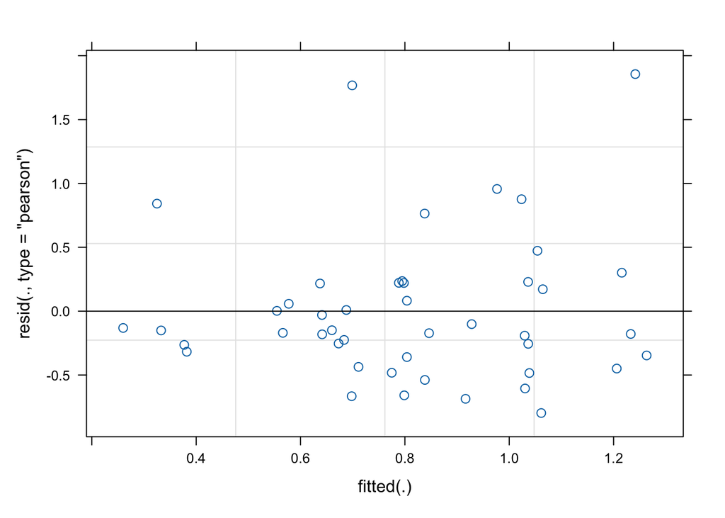

```r
plot(m1)
```

```r
m2 <- lmer(LRR.tot     ~ Rye.kgha + (1|CropYear), data = psa, na.action = na.omit) #log response ratio
```

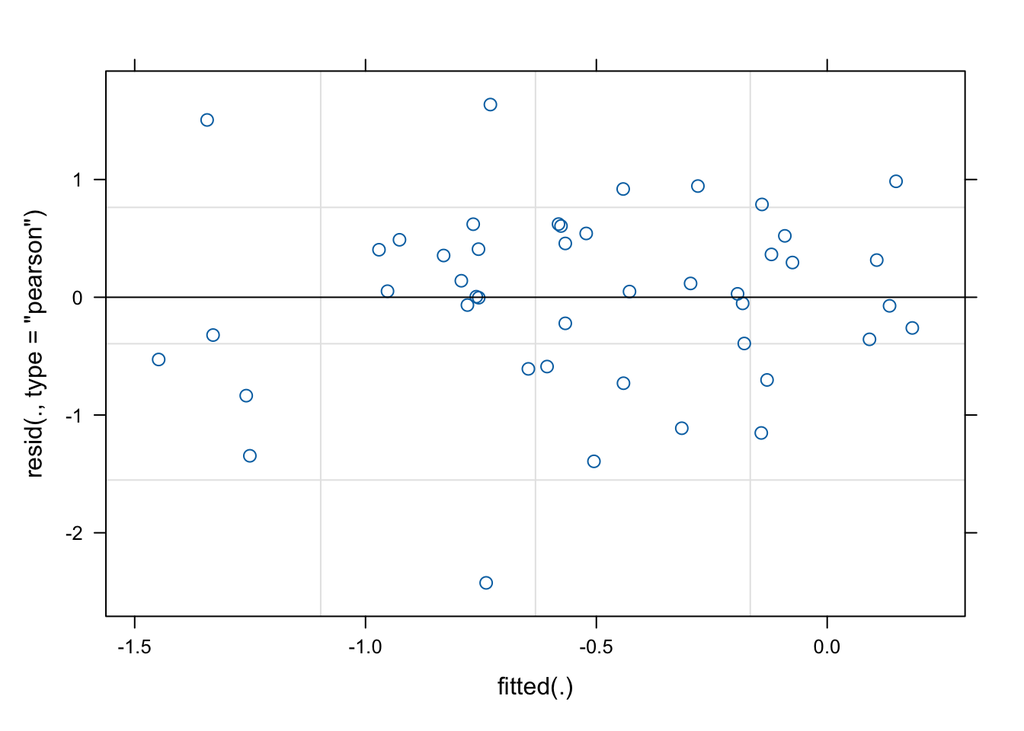

```r
plot(m2)      # inspect residuals to inspect homogeneity of variance (choose best fit)
```

## 2b. LME Regression (random intercept model vs. random intercept/slope model)

compare the AIC between models

```r
m1 <- lmer(LRR.tot      ~ Rye.kgha + (1|CropYear), data = psa, na.action = na.omit)
m2 <- lmer(LRR.tot      ~ Rye.kgha + (Rye.kgha|CropYear), data = psa, na.action = na.omit)
```

```
## boundary (singular) fit: see help('isSingular')
```

```r
anova(m1, m2) # check AICs ### random slop did not improve fit here
```

```
## refitting model(s) with ML (instead of REML)
```

```
## Data: psa
## Models:
## m1: LRR.tot ~ Rye.kgha + (1 | CropYear)
## m2: LRR.tot ~ Rye.kgha + (Rye.kgha | CropYear)
##    npar    AIC    BIC  logLik deviance  Chisq Df Pr(>Chisq)
## m1    4 117.69 124.92 -54.845   109.69
## m2    6 120.47 131.31 -54.233   108.47 1.2244  2     0.5422
```

NOTE: when calculation response ratios without spiked weeds, should standardize weeds to overall weedy check (not at replicate level)

## 3. Extract test-statistics and parameter estimates of best fit model

```r
m0 <- lmer(LRR.tot ~            (1|CropYear), data = psa, na.action = na.omit)
m1 <- lmer(LRR.tot ~ Rye.kgha + (1|CropYear), data = psa, na.action = na.omit)
```

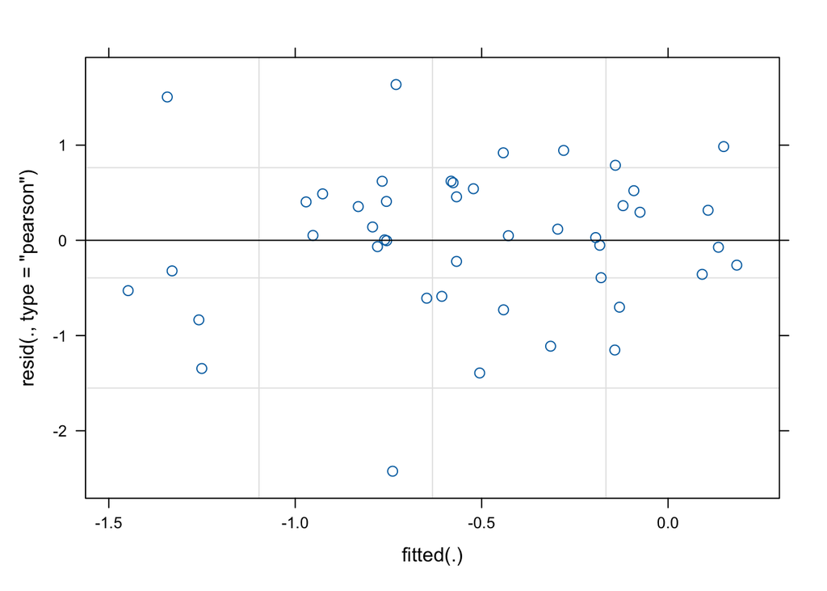

```r
plot(m1)      # inspect residuals to inspect homogeneity of variance (choose best fit)
```

```r
summary(m1)   # inspect parameter estimates
```

```
## Linear mixed model fit by REML ['lmerMod']
## Formula: LRR.tot ~ Rye.kgha + (1 | CropYear)
##    Data: psa
##
## REML criterion at convergence: 128.1
##
## Scaled residuals:
##      Min       1Q   Median       3Q      Max
## -3.02667 -0.48978  0.06071  0.60920  2.04227
##
## Random effects:
##  Groups   Name        Variance Std.Dev.
##  CropYear (Intercept) 0.1297   0.3601
##  Residual             0.6421   0.8013
## Number of obs: 45, groups:  CropYear, 3
##
## Fixed effects:
##               Estimate Std. Error t value
## (Intercept)  3.964e-02  3.203e-01   0.124
## Rye.kgha    -2.070e-04  7.746e-05  -2.673
##
## Correlation of Fixed Effects:
##          (Intr)
## Rye.kgha -0.663
## fit warnings:
## Some predictor variables are on very different scales: consider rescaling
```

```r
anova(m0, m1) # model significance: extract Wald Chi Sq & p-value
```

```
## refitting model(s) with ML (instead of REML)
```

```
## Data: psa
## Models:
## m0: LRR.tot ~ (1 | CropYear)
## m1: LRR.tot ~ Rye.kgha + (1 | CropYear)
##    npar    AIC    BIC  logLik deviance  Chisq Df Pr(>Chisq)
## m0    3 122.61 128.03 -58.303   116.61
## m1    4 117.69 124.92 -54.845   109.69 6.9147  1   0.008549 **
## ---
## Signif. codes:  0 '***' 0.001 '**' 0.01 '*' 0.05 '.' 0.1 ' ' 1
```

```r
#library(piecewiseSEM) # package to extract marginal & conditional r2 values
rsquared(m1, method=NULL) # use to extract conditional r2 value
```

```
##   Response   family     link method  Marginal Conditional
## 1  LRR.tot gaussian identity   none 0.1367518   0.2818113
```

## 4a. Extract and plot fitted model at the *random effects level*

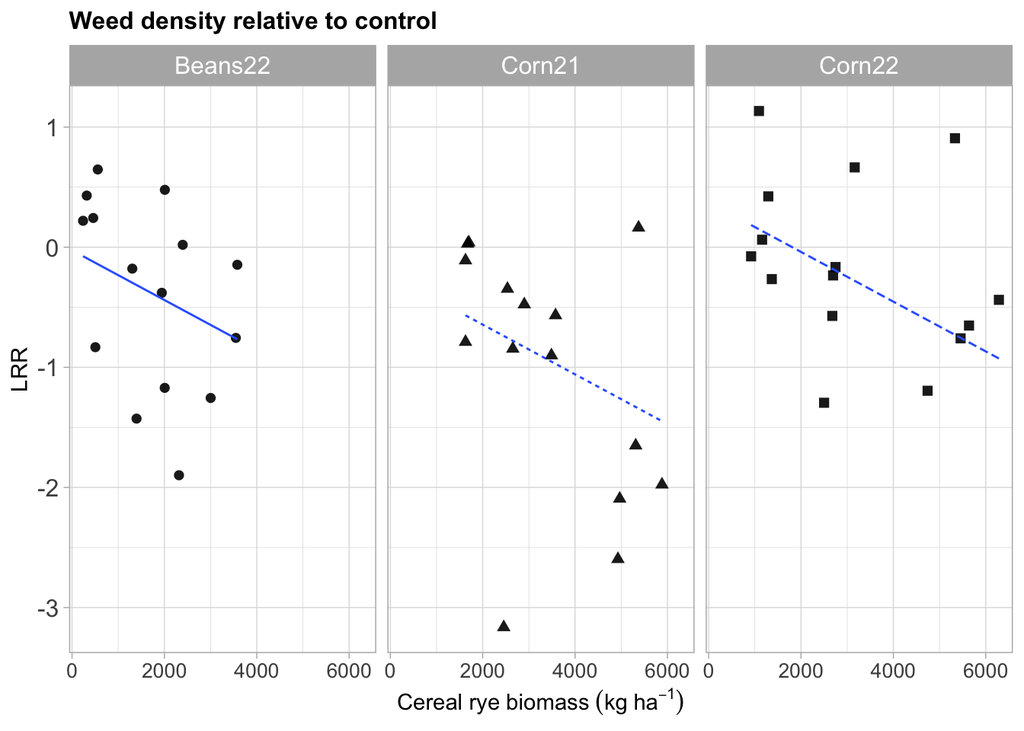

```r
#library(merTools)
psa$fit.ranef = predict(m1)
fig.rand <- ggplot(psa, aes(x = Rye.kgha, y = LRR.tot, shape = CropYear)) +
  theme_light() +
  geom_point(size=2.0, alpha=0.9) + # point features
  geom_smooth(method="lm", aes(x = Rye.kgha, y = fit.ranef, lty = CropYear), size = 0.5, alpha = 0.2) +
  facet_grid (. ~ CropYear) +
  xlab ("Cereal rye biomass" ~ (kg ~ ha^{-1})) +
  ylab("LRR") +
  ggtitle ("Weed density relative to control") +
  theme(legend.position = "none") +
  theme(legend.title = element_blank()) +
  theme(axis.text.x = element_text(size=10)) +
  theme(axis.text.y = element_text(size=12)) +
  theme(strip.text.x = element_text(size = 12)) +
  theme(plot.title = element_text(size = 12, face = "bold"))
fig.rand ### rand intercept model: diff interecepts, same slope
```

```r
#####
#theme(axis.title.y = element_blank()) +
#theme(panel.grid.minor.x = element_blank()) +
#theme(panel.grid.major.x = element_blank()) +
#scale_fill_manual(values=c("14-21 DPP" = "peru", "3-7 DPP"="gold", "1-3 DAP"="sea green")) +
#scale_color_manual(values=c("14-21 DPP" = "peru", "3-7 DPP"="gold", "1-3 DAP"="sea green")) +
#scale_x_continuous (limits = c(0, 1)) +
#scale_y_continuous (limits = c(-99, 20)) + # setting axis range; scale_y_continuous or scale_x_continuous
#####
```

## 4B. Extract and plot fitted model at the *population-estimate level*

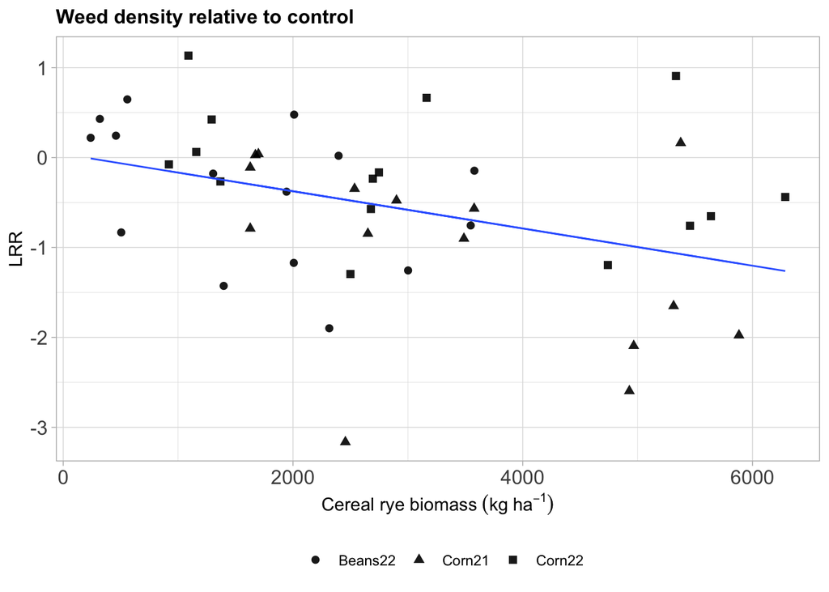

```r
psa$fit.popef = predict(m1, re.form = NA)
fig.popest <- ggplot(psa, aes(x = Rye.kgha, y = LRR.tot, shape = CropYear)) +
  theme_light() +
  geom_point(size=2.0, alpha=0.9) + # point features
  geom_smooth(method="lm", aes(x = Rye.kgha, y = fit.popef), size = 0.5, alpha = 0.2) +
  xlab ("Cereal rye biomass" ~ (kg ~ ha^{-1})) +
  ylab("LRR") +
  ggtitle ("Weed density relative to control") +
  theme(legend.position = "bottom") +
  theme(legend.title = element_blank()) +
  theme(axis.text.x = element_text(size=12)) +
  theme(axis.text.y = element_text(size=12)) +
  theme(strip.text.x = element_text(size = 12)) +
  theme(plot.title = element_text(size = 12, face = "bold"))
fig.popest  ### gaining biomass gradient by combining site years. but not explaining lots of variation in the model
```

```r
#####
#theme(axis.title.y = element_blank()) +
#theme(panel.grid.minor.x = element_blank()) +
#theme(panel.grid.major.x = element_blank()) +
#scale_fill_manual(values=c("14-21 DPP" = "peru", "3-7 DPP"="gold", "1-3 DAP"="sea green")) +
#scale_color_manual(values=c("14-21 DPP" = "peru", "3-7 DPP"="gold", "1-3 DAP"="sea green")) +
#scale_x_continuous (limits = c(0, 1)) +
#scale_y_continuous (limits = c(-99, 20)) + # setting axis range; scale_y_continuous or scale_x_continuous
#####
#ggsave(file="/Users/johnwallace/Documents/Documents/R/PSA.f1.jpg", scale=1.5, width=4.0, height=2.0, units="in", dpi=900)
```

## 5a. Extract and plot intercepts for random effects (i.e., BLUPs or conditional means)

```r
#library(broom.mixed) # package for extracting random effects of interest w/ CIs
r1 <- broom.mixed::tidy(m1, effects = "ran_vals", conf.int = TRUE, response = TRUE)
as.data.frame(r1)
```

```
##     effect    group   level        term    estimate std.error    conf.low
## 1 ran_vals CropYear Beans22 (Intercept) -0.06535315  0.179394 -0.41695887
## 2 ran_vals CropYear  Corn21 (Intercept) -0.26984846  0.179394 -0.62145418
## 3 ran_vals CropYear  Corn22 (Intercept)  0.33520160  0.179394 -0.01640412
##    conf.high
## 1 0.28625258
## 2 0.08175727
## 3 0.68680733
```

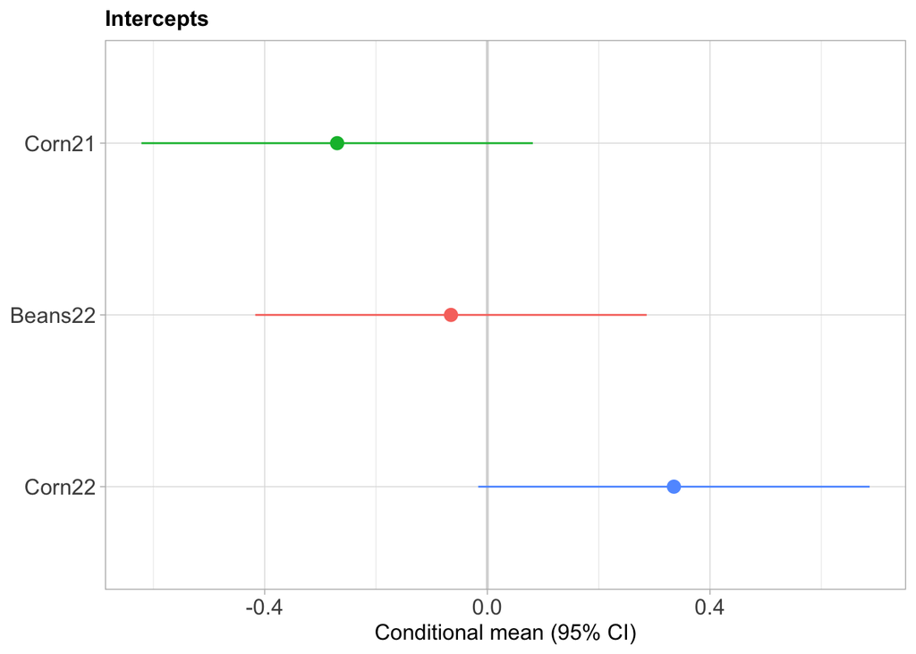

```r
intercept <- subset(r1, term == "(Intercept)")
fig.int <-ggplot(intercept, aes (x = reorder(level, -estimate), y = estimate, ymin = conf.low, ymax = conf.high, fill = level, color = level, shape = level)) + # extracted from summary data
  geom_hline(yintercept = 0, color = "gray85", size=0.75) +
  geom_errorbar(width = 0.0, size=0.5, position=position_dodge(0.9)) +
  geom_point(size=3.0, shape=21, position=position_dodge(0.9)) +
  coord_flip() +
  ggtitle ("Intercepts") + # optional title in quotes
  theme_light () + # several themes available, other: theme_minimal, theme_grey, theme_classic
  xlab (NULL) + # use this to remove axis title
  ylab ("Conditional mean (95% CI)") + #Label syntax is complicated; but is a typical layout
  theme(legend.position = "NULL") + #legend placement, can be: right, left, top
  theme(legend.title=element_blank()) + #removes legend title
  theme(axis.text.x = element_text(size=12)) +
  theme(axis.text.y = element_text(size=12)) +
  theme(axis.title.y = element_text(size=12)) +
  theme(axis.title.x = element_text(size=12)) +
  #theme(panel.grid.major.x = element_blank()) +
  #theme(panel.grid.major.y = element_blank()) +
  #theme(panel.grid.minor.x = element_blank()) +
  theme(plot.title = element_text(size = 12, face = "bold"))
fig.int
```

```r
#ggsave(file="/Users/johnwallace/Documents/Documents/R/PSA.f1.jpg", scale=1.5, width=4.0, height=2.0, units="in", dpi=900)
```

## 6. ICC (Intraclass Correlation Coefficients) *for nested structures*

proportion of total variance explained at each grouping level

```r
icc <-  VarCorr(m1) %>%
  as_data_frame() %>%
  mutate(icc=vcov/sum(vcov))
icc.df <- as.data.frame(icc)
icc.df
```

```
##        grp        var1 var2      vcov     sdcor       icc
## 1 CropYear (Intercept) <NA> 0.1296844 0.3601172 0.1680391
## 2 Residual        <NA> <NA> 0.6420668 0.8012907 0.8319609
```

[figure not shown]

```r
var <- c("Variable", "Variable")
grp <- c("GroupA", "Groupb")
icc <- c(00, 00) # input these ICC scores icc.df data frame using percentages
df <- data.frame(var, grp, icc) # create a data frame
df$grp = factor(df$grp, levels=c("GroupA", "GroupB")) # Order explanatory variables in order of ICC score (descending)
cbPalette <- c("#999999", "#E69F00")
ICC.plot <-ggplot(df, aes (x = var, y = icc)) + # extracted from summary data
  #geom_bar(aes(fill=grp, position="fill", stat="identity")) + # use this when you have more than one stacked bar
  geom_col(aes(fill=grp)) + # use this if plotting a single stacked bar
  coord_flip() +
  ggtitle ("Intraclass correlation coefficient") + # optional title in quotes
  theme_light() + # several themes available, other: theme_minimal, theme_grey, theme_classic
  xlab (NULL) + # use this to remove axis title
  ylab ("variance explained (%)") + #Label syntax is complicated; but is a typical layout
  theme(legend.position = "bottom") + #legend placement, can be: right, left, top
  theme(legend.title=element_blank()) + #removes legend title
  #scale_y_continuous (limits = c(0, 100)) +
  # scale_x_break(c(0.75, 0.95)) +
  theme(axis.text.x = element_text(size=12)) +
  theme(axis.title.x = element_text(size=12)) +
  theme(axis.text.y = element_blank()) +
  theme(axis.title.y = element_blank()) +
  theme(legend.text = element_text(size=10)) +
  theme(panel.grid.major.x = element_blank()) +
  theme(panel.grid.minor.x = element_blank()) +
  scale_fill_manual(values=c("GroupA" = "#CCCCCC", "GroupB" = "#E69F00"))
ICC.plot
```

```r
#ggsave(file="/Users/johnwallace/Documents/Documents/R/vt-f1b.jpg", scale=1.33, width=3.5, height=1.5, units="in", dpi=900)
```

# **STEPS 2-5: Hypothesized diagrams & tests of independence in piecewiseSEM package**

```r
basis.psa = psem(
  lmer(Rye.kgha ~ CC.win   + (CC.win|CropYear), data = psa, na.action = na.omit),
  lmer(LRR.tot  ~ Rye.kgha + (1|CropYear),      data = psa, na.action = na.omit)
)
basisSet(basis.psa) # Identifies indepedence claims in basis set
```

```
## $`Claim 1`
## [1] "CC.win | LRR.tot ( Rye.kgha )"
```

```r
dSep (basis.psa)    # Test of directed separation for individual claim; (should I include another term?)
```

```
##           Independ.Claim Test.Type      DF Crit.Value  P.Value
## 1 LRR.tot ~ CC.win + ...      coef 28.4679  0.4538386 0.505951
```

```r
                    # p < 0.05 indicates it should be included to improve model fit
fisherC(basis.psa)  # Model-wide test-statistic and P-value when multiple dSep tests (did my data fit the SEM?)
```

```
##   Fisher.C df P.Value
## 1    1.363  2   0.506
```

```r
                    # p > 0.05 indicates that data support the hypothesized model structure
summary(basis.psa)  # Produces all test statistics, reg & correlation coefficients
```

```
##
## Structural Equation Model of basis.psa
##
## Call:
##   Rye.kgha ~ CC.win
##   LRR.tot ~ Rye.kgha
##
##     AIC
##  843.960
##
## ---
## Tests of directed separation:
##
##           Independ.Claim Test.Type      DF Crit.Value P.Value
##   LRR.tot ~ CC.win + ...      coef 28.4679     0.4538   0.506
##
## --
## Global goodness-of-fit:
##
## Chi-Squared = NA with P-value = NA and on 1 degrees of freedom
## Fisher's C = 1.363 with P-value = 0.506 and on 2 degrees of freedom
##
## ---
## Coefficients:
##
##   Response Predictor Estimate Std.Error      DF Crit.Value P.Value Std.Estimate
##   Rye.kgha    CC.win 154.8823   21.7003  2.0000    50.9413  0.0191       0.8097
##    LRR.tot  Rye.kgha  -0.0002    0.0001 42.8579     6.3833  0.0153      -0.3834
##
##   *
##   *
##
##   Signif. codes:  0 '***' 0.001 '**' 0.01 '*' 0.05
##
## ---
## Individual R-squared:
##
##   Response method Marginal Conditional
##   Rye.kgha   none     0.60        0.87
##    LRR.tot   none     0.14        0.28
```

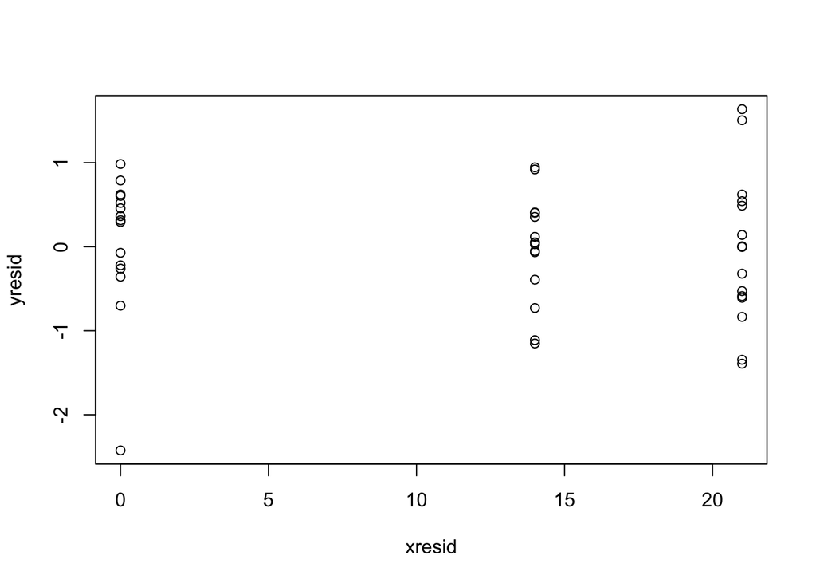

```r
                    # No chi-sq estimate or warnings may result from convergence issue in submodel
                    # Either tweak model parameters to converge or rely on Fisher's C
### use Std.Estimate (standardized regression coefficient), not "estimate" to make inference about strength of the relationship
##### put those on the final SEM fig.
part.resid <- partialResid(LRR.tot ~ CC.win, basis.psa) # Extract and inspect PARTIAL RESIDUALS
# Removes variation explained by x1 so partial of effect of x2 can be modeled
with(part.resid, plot(xresid, yresid))              # plot partial residuals
```

```r
as.data.frame(part.resid)                           # extract as data.frame
```

```
##          yresid xresid
## 1   0.542006179     21
## 2   0.363936767      0
## 3   0.117418323     14
## 4  -1.393321849     21
## 5   0.919446150     14
## 6   0.521519745      0
## 7  -1.112157741     14
## 8   0.788351206      0
## 9   0.005082515     21
## 10 -0.608000457     21
## 11 -0.702134663      0
## 12 -0.729926992     14
## 13  0.295102997      0
## 14  0.620469994     21
```

[output cut: 31 more lines]

```r
### use to test if something else you're not modeling is going on (or if it's not linear)
```